# Ten Tremendous Tricks

# Ten Tidyverse Tricks using Diamond dataset

[Video](https://www.youtube.com/watch?v=NDHSBUN_rVU). Thank you David Robinson!

```r
library(tidyverse)
```

```r
library(broom) # for 'tidy'
library(purrr) # for 'map'
```

### 1. count()

Display a sorted frequency table of number diamonds in each Clarity group

```r
diamonds %>% count(clarity, sort=T, name = "Number")  # sortedfreq
```

```
## # A tibble: 8 x 2
##   clarity Number
##   <ord>    <int>
## 1 SI1      13065
## 2 VS2      12258
## 3 SI2       9194
## 4 VS1       8171
## 5 VVS2      5066
## 6 VVS1      3655
## 7 IF        1790
## 8 I1         741
```

```r
diamonds %>% count(clarity, wt=price, sort=T)  # sum of Price for each Clarity group
```

```
## # A tibble: 8 x 2
##   clarity        n
##   <ord>      <int>
## 1 SI1     52207755
## 2 VS2     48112520
## 3 SI2     46549485
## 4 VS1     31372190
## 5 VVS2    16635412
## 6 VVS1     9221984
## 7 IF       5128062
## 8 I1       2907809
```

### 2. creating variables in count()

Show number of diamonds in each $1000 price range

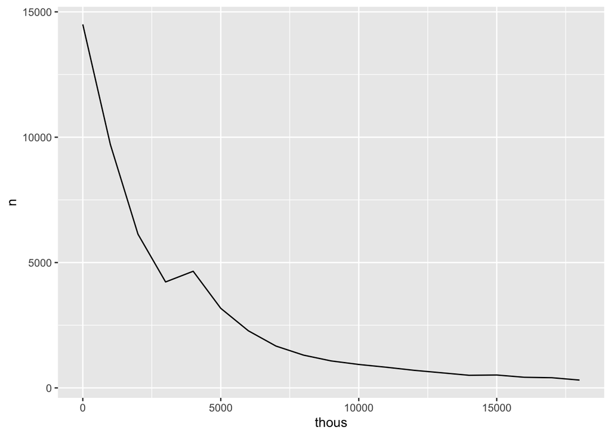

```r
diamonds %>% count(thous = 1000 * price %/% 1000) %>% ggplot(aes(thous, n)) +
  geom_line()
```

### 3. add_count()

Add column to diamonds showing the number of diamonds in each Clarity group

```r
diamonds %>% add_count(clarity)
```

```
## # A tibble: 53,940 x 11
##    carat cut       color clarity depth table price     x     y     z     n
##    <dbl> <ord>     <ord> <ord>   <dbl> <dbl> <int> <dbl> <dbl> <dbl> <int>
##  1 0.23  Ideal     E     SI2      61.5    55   326  3.95  3.98  2.43  9194
##  2 0.21  Premium   E     SI1      59.8    61   326  3.89  3.84  2.31 13065
##  3 0.23  Good      E     VS1      56.9    65   327  4.05  4.07  2.31  8171
##  4 0.290 Premium   I     VS2      62.4    58   334  4.2   4.23  2.63 12258
##  5 0.31  Good      J     SI2      63.3    58   335  4.34  4.35  2.75  9194
##  6 0.24  Very Good J     VVS2     62.8    57   336  3.94  3.96  2.48  5066
##  7 0.24  Very Good I     VVS1     62.3    57   336  3.95  3.98  2.47  3655
##  8 0.26  Very Good H     SI1      61.9    55   337  4.07  4.11  2.53 13065
##  9 0.22  Fair      E     VS2      65.1    61   337  3.87  3.78  2.49 12258
## 10 0.23  Very Good H     VS1      59.4    61   338  4     4.05  2.39  8171
## # … with 53,930 more rows
```

```r
# select Clarity with > 3000 diamonds
diamonds %>% add_count(clarity) %>% filter(n>3000)
```

```
## # A tibble: 51,409 x 11
##    carat cut       color clarity depth table price     x     y     z     n
##    <dbl> <ord>     <ord> <ord>   <dbl> <dbl> <int> <dbl> <dbl> <dbl> <int>
##  1 0.23  Ideal     E     SI2      61.5    55   326  3.95  3.98  2.43  9194
##  2 0.21  Premium   E     SI1      59.8    61   326  3.89  3.84  2.31 13065
##  3 0.23  Good      E     VS1      56.9    65   327  4.05  4.07  2.31  8171
##  4 0.290 Premium   I     VS2      62.4    58   334  4.2   4.23  2.63 12258
##  5 0.31  Good      J     SI2      63.3    58   335  4.34  4.35  2.75  9194
##  6 0.24  Very Good J     VVS2     62.8    57   336  3.94  3.96  2.48  5066
##  7 0.24  Very Good I     VVS1     62.3    57   336  3.95  3.98  2.47  3655
##  8 0.26  Very Good H     SI1      61.9    55   337  4.07  4.11  2.53 13065
##  9 0.22  Fair      E     VS2      65.1    61   337  3.87  3.78  2.49 12258
## 10 0.23  Very Good H     VS1      59.4    61   338  4     4.05  2.39  8171
## # … with 51,399 more rows
```

### 4. summarize() w/ a list column

Test the NULL hypo that price is 4000 regardless of clarity t.test mu=4000 [video](https://youtu.be/NDHSBUN_rVU?t=576)

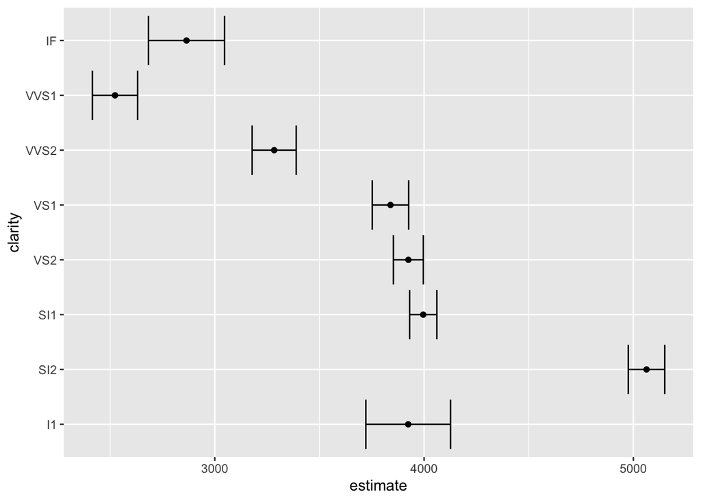

```r
ttests = diamonds %>% group_by(clarity) %>% summarize(t_test = list(t.test(price, mu=4000)))
ttests %>% mutate(tidied = map(t_test, tidy)) %>% unnest(tidied) %>%
  ggplot(aes(estimate, clarity)) + geom_point() +
  geom_errorbarh(aes(xmin = conf.low, xmax = conf.high))
```

### 5. fct_reorder + geom_col + coord_flip

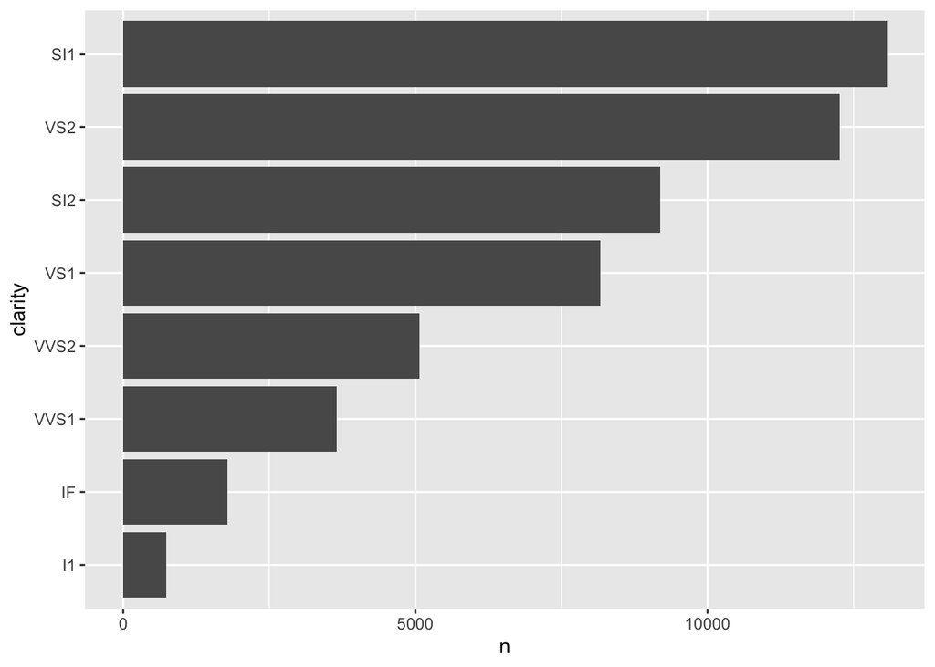

```r
# Reorder Clarity groups descending by total number of diamonds (on the fly!)
diamonds %>% count(clarity) %>% mutate(clarity = fct_reorder(clarity, n)) %>%
  ggplot(aes(clarity, n)) + geom_col() + coord_flip()
```

### 6. fct_lump()

Before using ‘lump’. This shows all Clarity groups. But lets say you want to only show the top 3 frequenct Clarity groups and LUMP all others into an Other category (see next plot)

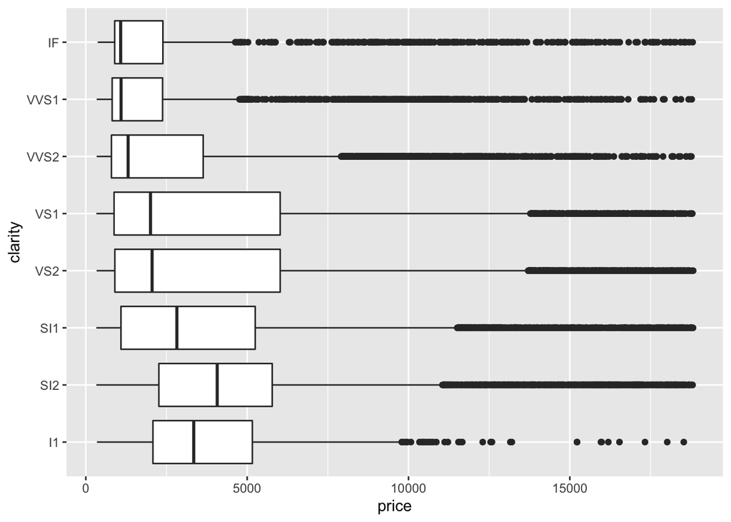

```r
diamonds %>% ggplot (aes(clarity, price)) + geom_boxplot() + coord_flip()
```

After using ‘fct_lump’. This lumps Clarity groups into Other if they are not the top 3 most frequent Clarity groups. Then reorder Clarity factor levels descending by ‘price’ using ‘fct_reorder’

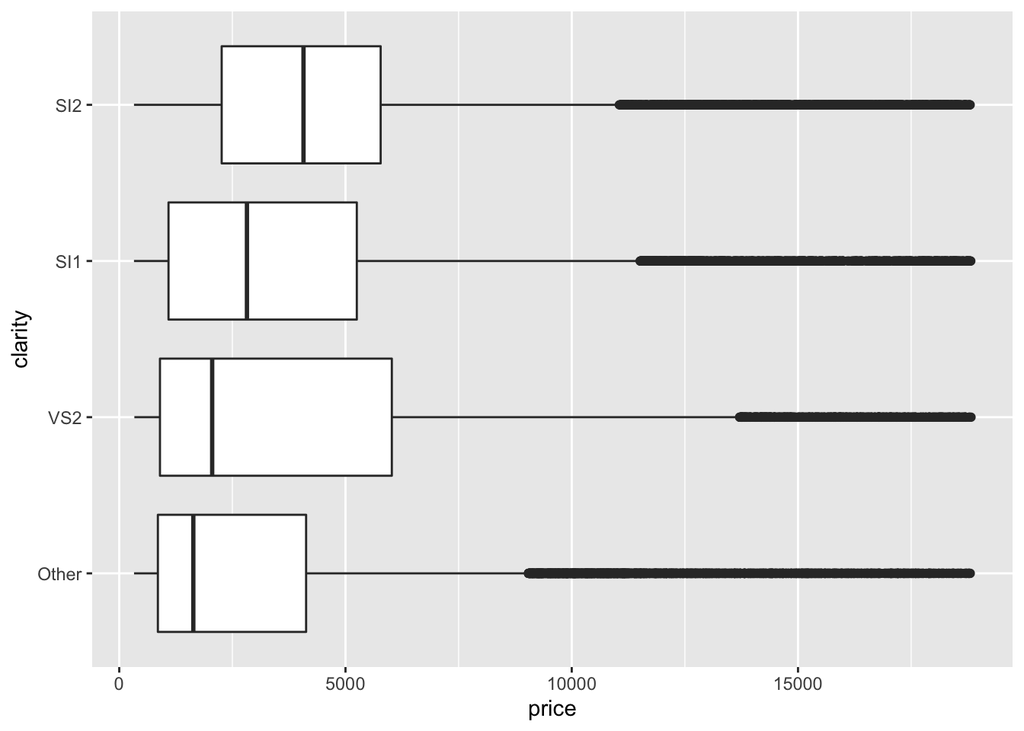

```r
diamonds %>% mutate(clarity=fct_lump(clarity,3), clarity=fct_reorder(clarity, price)) %>% ggplot (aes(clarity, price)) + geom_boxplot() + coord_flip()
```

### 7. Log scales scale_x/y_log10()

Alot of data is Log normal so let’s check the Carat distribution before and after Logging

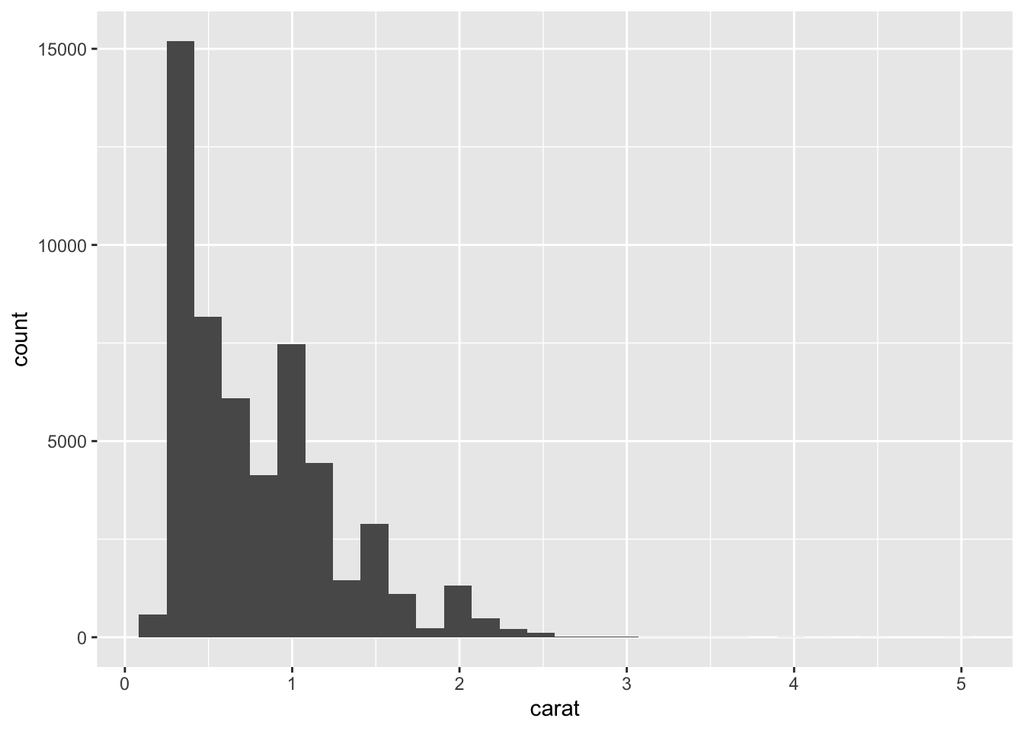

```r
diamonds %>% ggplot(aes(carat)) + geom_histogram()# + scale_x_log10()
```

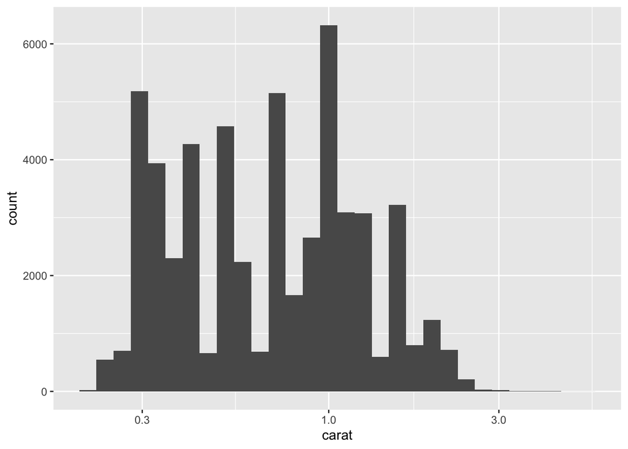

```r
diamonds %>% ggplot(aes(carat)) + geom_histogram() + scale_x_log10()
```

Perhaps(??) you get a better prediction of Price with Log Carat

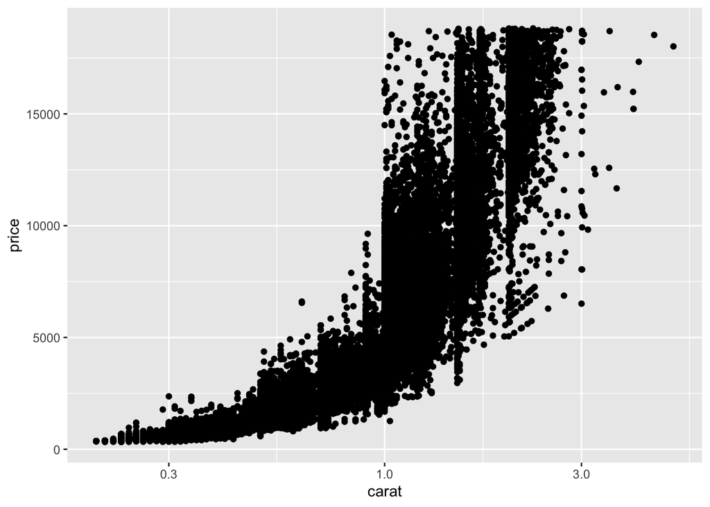

```r
diamonds %>% ggplot(aes(carat, price)) + geom_point() + scale_x_log10()
```